# Single-cell transcriptomics identifies an effectorness gradient shaping the response of CD4+ T cells to cytokines

Cano-Gomez et al., Nature Communications 11, 1801(2020)

2025-11-07

## RNA Sequencing

**RNA-seq Technology** is a powerful method used to analyze the transcriptome, which is the complete set of RNA molecules expressed in a cell or a population of cells. It allows researchers to measure gene expression levels, identify novel transcripts, and discover alternative splicing events.

Main Steps of RNA-seq Technology:

1. **Sample Collection**:
   - Biological samples (e.g., tissues or cells) are collected to extract RNA.
2. **RNA Extraction**:
   - The total RNA is isolated from the collected samples, focusing on messenger RNA (mRNA) since it carries the genetic information for protein synthesis.
3. **Library Preparation**:
   - The extracted mRNA is fragmented into smaller pieces, and specific adapters are added to both ends of these fragments. This process creates a library of cDNA (complementary DNA) that can be sequenced.
4. **Sequencing**:
   - The prepared library is sequenced using high-throughput sequencing technologies, generating millions of short nucleotide sequences (reads).
5. **Data Processing**:
   - The raw sequencing data is processed to remove low-quality reads and contaminants. The reads are then aligned to a reference genome or transcriptome.
6. **Quantification**:
   - The number of reads mapped to each gene is counted, providing a measure of gene expression levels.
7. **Normalization**:
   - The raw counts are normalized to account for differences in sequencing depth and library size, allowing for accurate comparisons across samples.
8. **Data Analysis**:
   - Statistical analyses are performed to identify differentially expressed genes, alternative splicing events, and other relevant biological insights.

     Challenges in RNA-seq Data Normalization
   - **Variable Sequencing Depth**:
     - Different samples may have varying total reads, leading to biased comparisons if not normalized.
   - **Library Size Differences**:
     - The total number of reads can differ between samples, affecting gene expression interpretation.
   - **Sparse Data**:
     - Many genes may have low or zero expression levels, complicating normalization and analysis.
   - **Batch Effects**:
     - Variations during sample processing or sequencing can confound results, requiring normalization to address these effects.
   - **Choice of Normalization Method**:
     - Various methods exist, and selecting the appropriate one can be challenging, as each has different assumptions.
   - **Biological Variability**:
     - Differences between samples (e.g., cell types or conditions) can affect gene expression, necessitating careful normalization.

## Dataset Description

This analysis uses **bulk RNA sequencing data** from human CD4+ T cells, originally generated by Cano-Gomez et al. (2020).

**Raw Counts (`RNA_seq_raw_counts.txt.gz`)**  
- **Size:** 58,051 genes × 94 samples.  
- **Format:** Rows are genes (Ensembl IDs), columns are samples. Values are raw read counts.

**Metadata (`bulk_RNAseq_metadata.txt.gz`)**  
- **Size:** 94 samples × 10 variables.  
- **Variables:** - `sample_id`: Sample identifier  
- `cell_type`: CD4+ T cell subset (Naive, Memory)  
- `cytokine_condition`: Cytokine stimulation condition (IFNB, Th0, Th2, Th17, Resting)  
- `stimulation_time`: Duration of stimulation (16h, 5d)  
- `donor_id`: Donor identifier  
- `sex`: Donor sex  
- `age`: Donor age in years  
- `sequencing_batch`: Sequencing batch number  
- `cell_culture_batch`: Cell culture batch number

This dataset allows analysis of gene expression differences across cell types, stimulation conditions, and donors, controlling for batch effects.

## Loading and pre-processing

### Libraries

```r
if (!require("BiocManager", quietly = TRUE))
    install.packages("BiocManager")
BiocManager::install("DESeq2")
if (!require("BiocManager", quietly = TRUE))
    install.packages("BiocManager")

BiocManager::install("vsn")
library(DESeq2)
library(vsn)
```

### Loading expression data

This data is an example for processing **bulk RNA-sequencing (RNA-seq)** count data.  
In RNA-seq analysis, messenger RNA (mRNA) molecules are fragmented into small RNA reads that are subsequently sequenced. These reads are then **mapped to a reference genome**, and for each gene, the total number of mapped reads (or *counts*) is quantified.

The resulting **gene expression count matrix** typically contains:

- **Rows** → individual genes
- **Columns** → biological samples
- **Values** → raw read counts per gene per sample

This count matrix serves as the input for downstream analyses such as **normalization**, **differential expression**, and **functional enrichment**.

```r
# Set the working directory to access the data
setwd('/Users/systems/Desktop/Bioinformatics Course/bulk_RNA_seq')

ge_matrix = read.table("NCOMMS-19-7936188_bulk_RNAseq_raw_counts.txt.gz", header = TRUE)

dim(ge_matrix)
```

```
## [1] 58051    94
```

```r
# columns are samples
# rows are genes
# values are the number of the reads which are mapped to the genes in each sample

# Only a subset of data
ge_matrix[1:10, 1:10]
```

```
##                 I0712 I0713 I0717 I0721 I0726 I0731 I0732 I0734 I0735 I0736
## ENSG00000223972     0     0     0     0     0     0     0     0     2     1
## ENSG00000227232    55    93   198   131    75    64    90   101   164    70
## ENSG00000278267     6     6    28     5     4     9     6     8    13     2
## ENSG00000243485     0     0     0     3     1     0     0     0     0     0
## ENSG00000237613     0     0     0     0     0     0     0     0     0     0
## ENSG00000268020     0     0     1     0     0     0     0     0     0     0
## ENSG00000240361     0     0     0     0     0     0     0     0     0     0
## ENSG00000186092     0     0     0     0     0     0     0     0     0     0
## ENSG00000238009     1     0    14     0     0     0     0     0     0     1
## ENSG00000239945     0     0     0     0     0     0     0     0     0     0
```

### Loading Meta-data

Alongside the expression count matrix, **metadata** is required to describe the biological and experimental context of each sample.  
The metadata file typically includes information such as:

- **Sample ID** — unique identifier matching the column names in the count matrix
- **Phenotype / Condition** — e.g., control vs. treated, wild-type vs. mutant
- **Cell type or tissue** — biological source of the RNA
- **Batch or replicate information** — technical or biological replicates

```r
path <- "NCOMMS-19-7936188_bulk_RNAseq_metadata.txt.gz"

setwd('/Users/systems/Desktop/Bioinformatics Course/bulk_RNA_seq')

pheno_matrix <- read.table(path, header = TRUE, stringsAsFactors = TRUE)

pheno_matrix[1:10, 1:10]
```

```
##    sample_id  cell_type cytokine_condition stimulation_time donor_id  sex age
## 1      I0712  CD4_Naive               IFNB              16h      257 Male  38
## 2      I0713  CD4_Naive               Th17              16h      254 Male  58
## 6      I0717 CD4_Memory            Resting               5d      265 Male  59
## 10     I0721  CD4_Naive                Th2               5d      257 Male  38
## 15     I0726 CD4_Memory               Th17               5d      264 Male  27
## 20     I0731  CD4_Naive                Th0              16h      257 Male  38
## 21     I0732  CD4_Naive                Th2               5d      257 Male  38
## 23     I0734 CD4_Memory                Th0              16h      265 Male  59
## 24     I0735  CD4_Naive            Resting               5d      254 Male  58
## 25     I0736 CD4_Memory                Th2               5d      264 Male  27
##    sequencing_batch cell_culture_batch rna_integrity_number
## 1                 1                  3                  9.5
## 2                 1                  3                  9.3
## 6                 1                  4                  9.7
## 10                1                  3                 10.0
## 15                1                  4                  9.9
## 20                1                  3                  9.4
## 21                1                  3                  9.8
## 23                1                  4                  9.4
## 24                1                  3                  8.0
## 25                1                  4                  9.8
```

```r
dim(pheno_matrix)
```

```
## [1] 94 10
```

## Organizing data

Before analysis, it’s crucial to ensure that the **sample identifiers** in the metadata correspond exactly to the **sample columns** in the expression matrix.  
Both datasets must have the same samples in the same order to avoid misalignment during downstream analysis.

```r
# Assign sample IDs as row names in the metadata
rownames(pheno_matrix) <-  pheno_matrix$sample_id

# Inspect dimensions and structure
dim(pheno_matrix)
```

```
## [1] 94 10
```

```r
head(pheno_matrix)
```

```
##       sample_id  cell_type cytokine_condition stimulation_time donor_id  sex
## I0712     I0712  CD4_Naive               IFNB              16h      257 Male
## I0713     I0713  CD4_Naive               Th17              16h      254 Male
## I0717     I0717 CD4_Memory            Resting               5d      265 Male
## I0721     I0721  CD4_Naive                Th2               5d      257 Male
## I0726     I0726 CD4_Memory               Th17               5d      264 Male
## I0731     I0731  CD4_Naive                Th0              16h      257 Male
##       age sequencing_batch cell_culture_batch rna_integrity_number
## I0712  38                1                  3                  9.5
## I0713  58                1                  3                  9.3
## I0717  59                1                  4                  9.7
## I0721  38                1                  3                 10.0
## I0726  27                1                  4                  9.9
## I0731  38                1                  3                  9.4
```

```r
# Verify sample alignment between metadata and expression matrix
all(rownames(pheno_matrix) == colnames(ge_matrix))
```

```
## [1] TRUE
```

The output is `TRUE`, o the metadata and expression data are correctly aligned. Otherwise, reordering or subsetting would be required before proceeding.

```r
colnames(pheno_matrix)
```

```
##  [1] "sample_id"            "cell_type"            "cytokine_condition"
##  [4] "stimulation_time"     "donor_id"             "sex"
##  [7] "age"                  "sequencing_batch"     "cell_culture_batch"
## [10] "rna_integrity_number"
```

```r
pheno_matrix$stimulation_time
```

```
##  [1] 16h 16h 5d  5d  5d  16h 5d  16h 5d  5d  5d  16h 16h 16h 16h 5d  16h 5d  5d
## [20] 16h 5d  5d  16h 5d  16h 5d  5d  16h 16h 16h 5d  16h 16h 5d  16h 16h 5d  16h
## [39] 5d  16h 5d  16h 5d  5d  16h 16h 5d  5d  5d  16h 5d  5d  16h 16h 5d  16h 5d
## [58] 16h 5d  16h 5d  16h 5d  16h 5d  5d  16h 16h 5d  16h 16h 16h 5d  16h 5d  16h
## [77] 5d  16h 5d  5d  5d  5d  16h 5d  5d  16h 16h 5d  5d  16h 16h 16h 5d  16h
## Levels: 16h 5d
```

### Sub-setting data

For the purpose of this analysis, we focus on a specific subset of samples:  
**CD4⁺ memory T cells** collected **after 5 days of treatment** compared to **control** conditions.

Filtering the dataset to this subset ensures that the differential expression results specifically reflect the treatment effect in this cell type and time point.

```r
# Subset metadata for CD4+ memory cells at day 5
stimulation_time    <- '5d'
conditions  <- c('Th2', 'Th0')
celltype    <- 'CD4_Memory'

toSelect <-  pheno_matrix$stimulation_time == stimulation_time &
  pheno_matrix$cytokine_condition %in% conditions &
  pheno_matrix$cell_type == celltype

# Subset expression matrix accordingly
pheno_matrix.subset <-pheno_matrix[toSelect, ]
ge_matrix.subset <-  ge_matrix [ ,toSelect]
```

## Creating DESeq2 object

To perform **differential expression analysis**, we create a `DESeqDataSet` object from the expression counts and corresponding metadata.  
The **design formula** specifies the biological variable of interest — in this case, the **cytokine condition** (TH2 vs. TH0) in **CD4⁺ memory cells** after 5 days.

```r
dds <-  DESeqDataSetFromMatrix(countData = ge_matrix.subset, #gene expression
                               colData = pheno_matrix.subset, #meta data
                               design = ~ cytokine_condition) #the question that is important to use to compare: we want to see the differece between CD4_Memory cells after 5 days in TH2 & TH0 condions
```

```
## factor levels were dropped which had no samples
```

```r
head(dds)
```

```
## class: DESeqDataSet
## dim: 6 9
## metadata(1): version
## assays(1): counts
## rownames(6): ENSG00000223972 ENSG00000227232 ... ENSG00000237613
##   ENSG00000268020
## rowData names(0):
## colnames(9): I0736 I0749 ... I0867 I0874
## colData names(10): sample_id cell_type ... cell_culture_batch
##   rna_integrity_number
```

### Filtering low-expressed gene

Before running the differential expression analysis, genes with **no or very low counts** across all samples should be removed.  
These genes add noise and reduce statistical power, as they don’t provide meaningful signal for DESeq2’s model.

```r
# This keeps genes that have at least 10 counts total across all samples, which is standard before differential expression (DE) testing.
keep <-  rowSums(counts(dds)) >= 10
dds <- dds[keep, ]
dds
```

```
## class: DESeqDataSet
## dim: 26656 9
## metadata(1): version
## assays(1): counts
## rownames(26656): ENSG00000227232 ENSG00000278267 ... ENSG00000271254
##   ENSG00000275405
## rowData names(0):
## colnames(9): I0736 I0749 ... I0867 I0874
## colData names(10): sample_id cell_type ... cell_culture_batch
##   rna_integrity_number
```

## Variance stabilization for visualization

While **DESeq2** operates on **raw count data** for statistical modeling, most visualization and exploratory analyses (e.g. PCA, clustering, correlation) assume data with an approximately **normal distribution**. To achieve this, we apply transformations that stabilize the variance across genes — especially those with low expression levels.

### Log2 transformation (with Pseudocount)

A simple approach is to apply a log₂ transformation with a small pseudocount (commonly 1) to avoid undefined values for zeros:

log2-transformed=log2(raw count+1)

example:

| Gene | Sample1 | Sample2 |
| --- | --- | --- |
| gene1 | 0 | 5 |
| gene2 | 10 | 0 |

After transformation:

| Gene | Sample1 | Sample2 |
| --- | --- | --- |
| gene1 | 0.00 | 2.58 |
| gene2 | 3.46 | 0.00 |

- Zero counts remain 0 (after adding pseudocount 1)
- High counts are **compressed**, reducing variance differences
- Patterns become easier to interpret in **PCA**, **heatmaps**, and **correlation plots**

#### ⚠️ Note on Low Counts

If low-count genes were **not filtered out** in the previous step, basic log-transformation may exaggerate noise.  
In such cases, use DESeq2’s **regularized transformations**, which handle variance more robustly:

```r
# Not to be run this cell for now
# Regularized log transformation
rld <- rlog(dds)
assay(rld)[1:5, 1:5]
```

```
##                     I0736     I0749     I0760     I0801     I0841
## ENSG00000227232 6.1928676 6.6566076 6.4993795 6.4370980 6.5683330
## ENSG00000278267 2.3726365 2.4408209 2.4951348 2.7333225 2.3886191
## ENSG00000233750 0.6449586 0.6512494 0.7178439 0.6252722 0.6241998
## ENSG00000268903 5.9816804 6.2202777 5.7502937 5.7437843 6.3287267
## ENSG00000269981 5.4728232 5.8793623 5.4410033 5.5061720 5.9602449
```

```r
# Variance stabilizing transformation
vsd <- vst(dds)
assay(vsd)[1:5, 1:5]
```

```
##                    I0736    I0749    I0760    I0801    I0841
## ENSG00000227232 6.979224 7.532803 7.343904 7.269999 7.427856
## ENSG00000278267 5.590149 5.740667 5.840875 6.189339 5.616963
## ENSG00000233750 5.590149 5.608803 5.756107 5.524428 5.520929
## ENSG00000268903 7.011374 7.290487 6.741494 6.723811 7.418825
## ENSG00000269981 6.655246 7.128147 6.618695 6.690100 7.223461
```

To visualize RNA-seq data, we often apply transformations that **stabilize variance across genes**. DESeq2 provides multiple options:

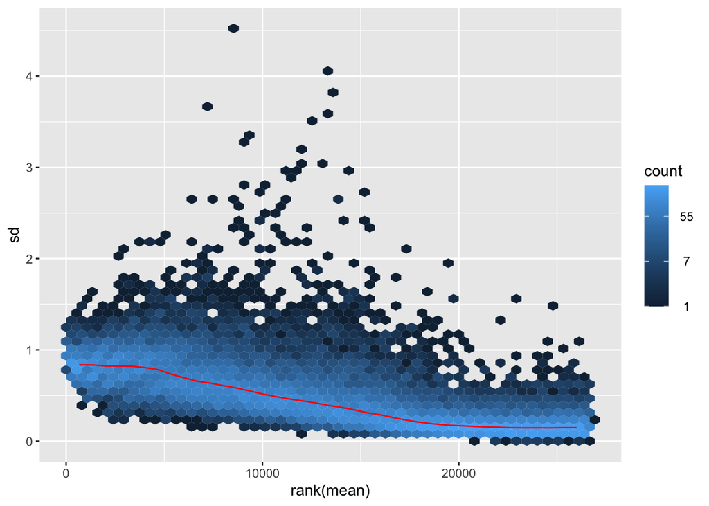

```r
# Apply a pseudocount of 1 and apply log2
# For DE testing, you don’t use normTransform(); it’s only for visualization. DESeq2 internally models counts directly.
normtfd <- normTransform(dds, f = log2, pc = 1)
# Compare mean to sd
meanSdPlot(assay(normtfd))
```

- Observations:
  - **Highly expressed genes** have relatively low standard deviation.
  - **Medium-expressed genes** can show high variance.
  - Standard deviation is **not homogeneous** across expression levels, which can bias clustering and visualization.
- **Important:** `normTransform()` is **only for visualization**, not for differential expression testing. DESeq2 internally models raw counts directly. One uses `normTransform()` mainly for **speed and convenience** in exploratory visualization when extreme precision isn’t critical.

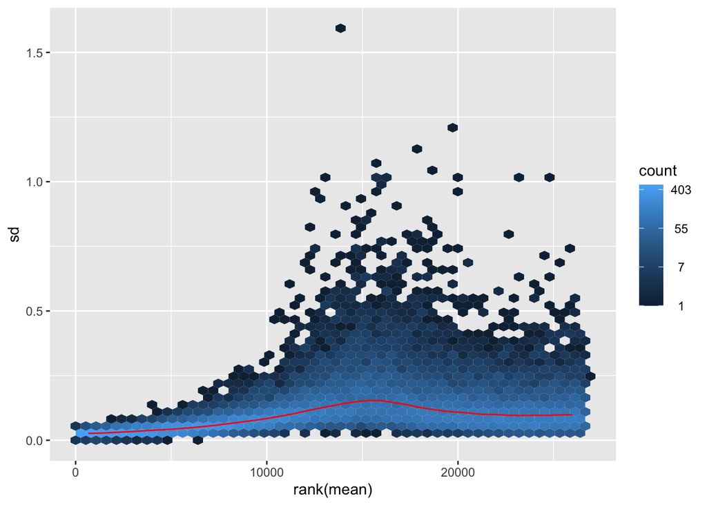

```r
# Let's calculate rlog values and take another look.
rltfd <- rlog(dds, blind=FALSE)
meanSdPlot(assay(rltfd))
```

- rlog stabilizes the variance across all expression levels, including low- and medium-expressed genes.
- After rlog, **standard deviations become more uniform**, making PCA, clustering, and heatmaps more interpretable.

### Normalization

RNA-seq libraries often have **different sequencing depths** — i.e., some samples have more total reads than others. Directly comparing raw counts between samples can therefore be misleading.

A simple approach like **Counts Per Million (CPM)** can make samples more comparable, but it is **highly sensitive to outliers**. For example, if a few genes are extremely highly expressed in one sample, CPM-based normalization can be skewed.

DESeq2 addresses this using **size factor normalization**:

- It identifies a set of **“stable” genes** whose expression is roughly consistent across samples.
- The **size factor** for each sample is calculated based on these genes.
- All raw counts in that sample are then **scaled by its size factor**, making samples comparable while accounting for sequencing depth and composition differences.

```r
dds <- estimateSizeFactors(dds)
# each sample has one size factor for seq depths
dds$sizeFactor
```

```
##     I0736     I0749     I0760     I0801     I0841     I0862     I0865     I0867
## 1.1643462 1.0323102 1.2059462 0.9525591 0.9814876 0.7809045 1.0499075 0.8574515
##     I0874
## 1.1081705
```

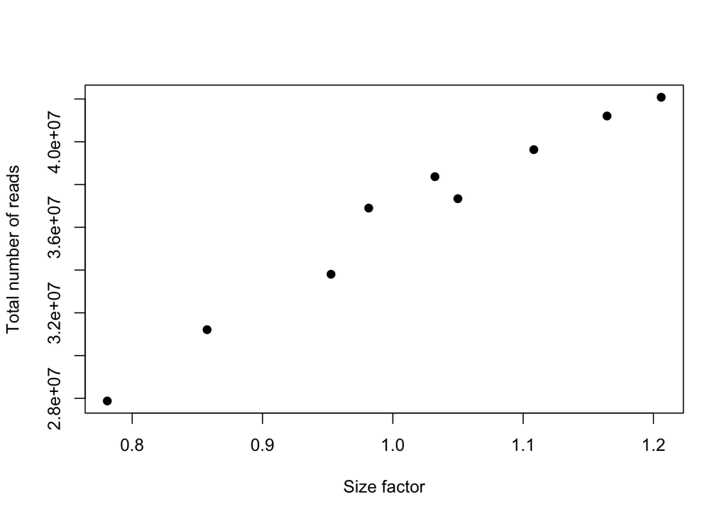

```r
plot(dds$sizeFactor,
    colSums(counts(dds, normalized=F)),
    xlab = 'Size factor',
    ylab = 'Total number of reads',
    pch = 19)
```

```r
dds$sizeFactor
```

```
##     I0736     I0749     I0760     I0801     I0841     I0862     I0865     I0867
## 1.1643462 1.0323102 1.2059462 0.9525591 0.9814876 0.7809045 1.0499075 0.8574515
##     I0874
## 1.1081705
```

- After applying size factors, DESeq2 effectively works with **pseudo counts** internally, which are adjusted counts used for statistical modeling.
- This ensures that downstream differential expression analysis is **not biased by library size or extreme outliers**.

## Principal componant analysis (PCA)

PCA is a standard technique to explore and visualize **overall patterns in gene expression data**.  
Since PCA assumes that features (genes) are roughly **normally distributed**, we first transform the count data using **rlog**to account for library size and stabilize variance.

```r
# Perform PCA on rlog-transformed data
rltfd.pca <-  prcomp(t(assay(rltfd)), scale = TRUE)
```

#### What does `scale = TRUE` do?

- Each gene (column) is **centered and scaled**:

  xscaled=x−mean(x)sd(x)
- This standardizes the variance across genes.

**Why it matters biologically:**

- Some genes, like **housekeeping genes**, are very highly expressed, while others, like **transcription factors**, have lower absolute expression.
- Without scaling, highly expressed genes dominate the principal components, potentially masking biologically meaningful variation in lowly expressed but variable genes.
- Scaling ensures that **all genes contribute equally** to the PCA, highlighting meaningful differences rather than just magnitude differences.

#### What does `scale = FALSE` do?

- **Interpretation:** PCA will give more weight to genes with **higher absolute variance** or expression levels.
- **Use case:**
  - You want to capture the **dominant signals** in the data, e.g., highly expressed genes or strong technical differences.
  - For example, if you’re analyzing **housekeeping genes or very high-count genes**, and their absolute expression differences are biologically meaningful, scaling could actually reduce that signal.

```r
require(factoextra)
```

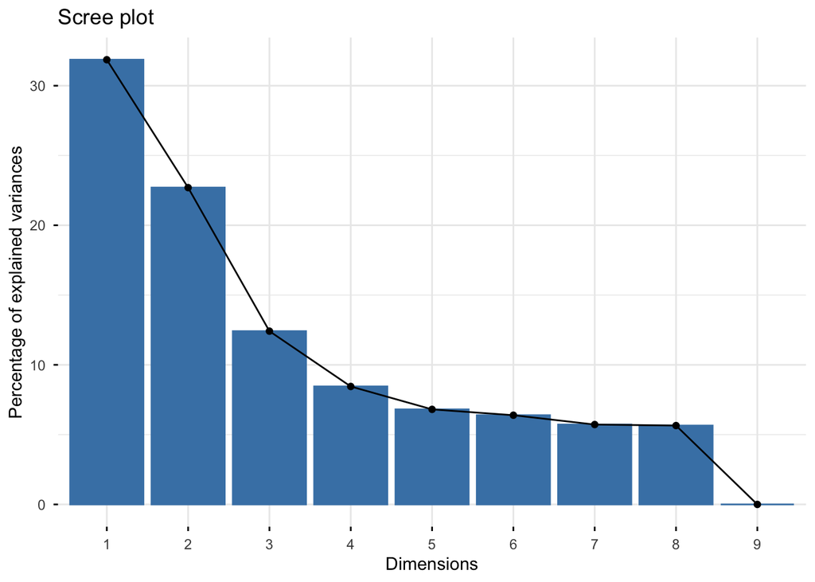

```r
fviz_eig(rltfd.pca)
```

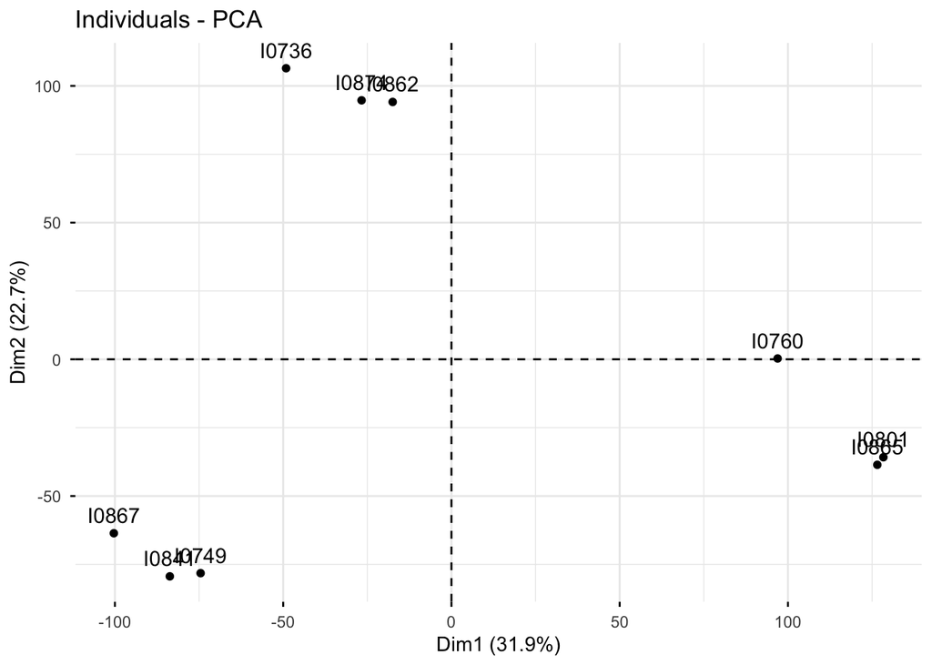

```r
fviz_pca_ind(rltfd.pca)
```

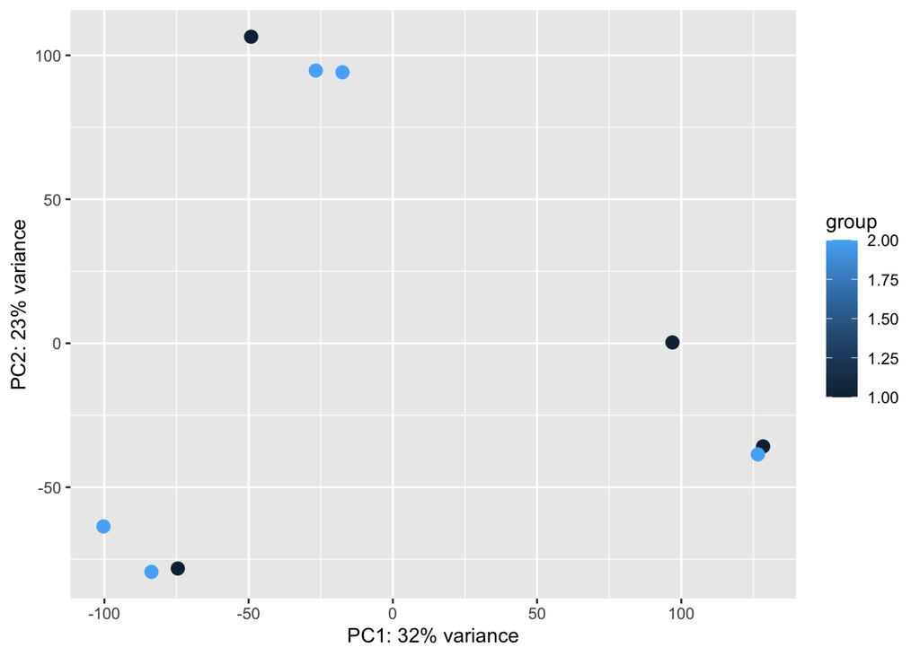

```r
object=rltfd
intgroup = 'sequencing_batch'
ntop=26656
returnData = FALSE

      rv <- MatrixGenerics::rowVars(assay(object))
      select <- order(rv, decreasing = TRUE)[seq_len(min(ntop,
            length(rv)))]
      #if the variabiloty is important we use scale
      #pca <- prcomp(t(assay(object)[, ]))
      pca <- prcomp(t(assay(object)[, ]),scale=TRUE)
      percentVar <- pca$sdev^2/sum(pca$sdev^2)

      if (!all(intgroup %in% names(colData(object)))) {
            stop("the argument 'intgroup' should specify columns of colData(dds)")
      }
        intgroup.df <- as.data.frame(colData(object)[, intgroup,
            drop = FALSE])
        group <- if (length(intgroup) > 1) {
            factor(apply(intgroup.df, 1, paste, collapse = ":"))
        } else {
            colData(object)[[intgroup]]
        }
        d <- data.frame(PC1 = pca$x[, 1], PC2 = pca$x[, 2], group = group,
            intgroup.df, name = colnames(object))
        if (returnData) {
            attr(d, "percentVar") <- percentVar[1:2]
            return(d)
        }
        ggplot(data = d, aes_string(x = "PC1", y = "PC2", color = "group")) +
            geom_point(size = 3) + xlab(paste0("PC1: ", round(percentVar[1] *
            100), "% variance")) + ylab(paste0("PC2: ", round(percentVar[2] *
            100), "% variance")) + coord_fixed()
```

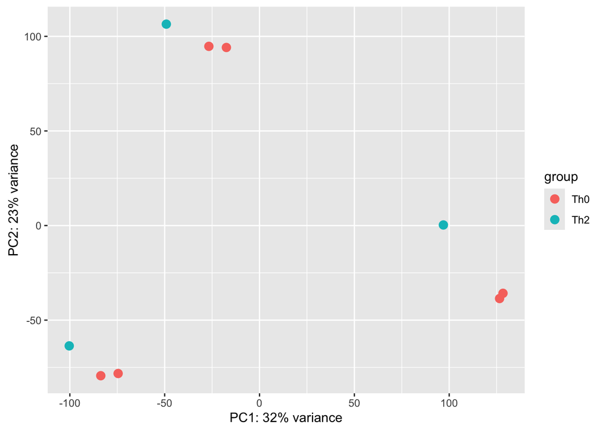

```r
object=rltfd
intgroup = 'cytokine_condition'
ntop=26656
returnData = FALSE

      rv <- MatrixGenerics::rowVars(assay(object))
      select <- order(rv, decreasing = TRUE)[seq_len(min(ntop,
            length(rv)))]
      #if the variabiloty is important we use scale
      #pca <- prcomp(t(assay(object)[, ]))
      pca <- prcomp(t(assay(object)[, ]),scale=TRUE)
      percentVar <- pca$sdev^2/sum(pca$sdev^2)

      if (!all(intgroup %in% names(colData(object)))) {
            stop("the argument 'intgroup' should specify columns of colData(dds)")
      }
        intgroup.df <- as.data.frame(colData(object)[, intgroup,
            drop = FALSE])
        group <- if (length(intgroup) > 1) {
            factor(apply(intgroup.df, 1, paste, collapse = ":"))
        } else {
            colData(object)[[intgroup]]
        }
        d <- data.frame(PC1 = pca$x[, 1], PC2 = pca$x[, 2], group = group,
            intgroup.df, name = colnames(object))
        if (returnData) {
            attr(d, "percentVar") <- percentVar[1:2]
            return(d)
        }
        ggplot(data = d, aes_string(x = "PC1", y = "PC2", color = "group")) +
            geom_point(size = 3) + xlab(paste0("PC1: ", round(percentVar[1] *
            100), "% variance")) + ylab(paste0("PC2: ", round(percentVar[2] *
            100), "% variance")) + coord_fixed()
```

## Differential expression analysis

RNA-seq data consists of **counts**, which are **not normally distributed**, making standard tests like the t-test unsuitable.

- **Model:** Counts are better described by a **negative binomial distribution**, which accounts for the mean–variance relationship.
- **Parameters:**
  - **Mean count** – average expression
  - **Overdispersion (α)** – how variance relates to the mean (low α ≈ variance close to mean)
- **Challenges:** Low sample sizes or lowly expressed genes can produce unstable variance estimates.
- **Solution:** DESeq2 and similar packages **shrink extreme variance and overdispersion estimates**, stabilizing results and enabling reliable identification of differentially expressed genes.

```r
library(DESeq2)
BiocManager::install("EnhancedVolcano")
library(EnhancedVolcano)
```

```r
library(pheatmap)
```

```r
dds <-  DESeq((dds))
# results: Extract results from a DESeq analysis giving base means across samples, log2 fold changes, standard errors, test statistics, p-values and adjusted p-values; resultsNames returns the names of the estimated effects (coefficents) of the model; removeResults returns a DESeqDataSet object with results columns removed

res <- results(dds)

dim(res)
```

```
## [1] 26656     6
```

```r
res
```

```
## log2 fold change (MLE): cytokine condition Th2 vs Th0
## Wald test p-value: cytokine condition Th2 vs Th0
## DataFrame with 26656 rows and 6 columns
##                  baseMean log2FoldChange     lfcSE       stat    pvalue
##                 <numeric>      <numeric> <numeric>  <numeric> <numeric>
## ENSG00000227232  88.95983      0.0223454  0.274133  0.0815127  0.935034
## ENSG00000278267   5.97875     -1.3153424  0.867645 -1.5159912  0.129522
## ENSG00000233750   1.53816      1.0398040  1.087345  0.9562782  0.338932
## ENSG00000268903  66.27922      0.1048259  0.377488  0.2776933  0.781248
## ENSG00000269981  50.99808     -0.1707947  0.355286 -0.4807244  0.630712
## ...                   ...            ...       ...        ...       ...
## ENSG00000276345  60.59217       0.227696  2.330880  0.0976868  0.922181
## ENSG00000277856   2.46383      -0.961505  0.975319 -0.9858360  0.324214
## ENSG00000275063   9.71461       0.523047  0.497266  1.0518458  0.292870
## ENSG00000271254  30.86838       0.123534  0.477830  0.2585305  0.795998
## ENSG00000275405   1.80653      -0.479047  1.294148 -0.3701642  0.711260
##                      padj
##                 <numeric>
## ENSG00000227232         1
## ENSG00000278267         1
## ENSG00000233750        NA
## ENSG00000268903         1
## ENSG00000269981         1
## ...                   ...
## ENSG00000276345         1
## ENSG00000277856         1
## ENSG00000275063         1
## ENSG00000271254         1
## ENSG00000275405        NA
```

| Column | Meaning | How to interpret |
| --- | --- | --- |

| **baseMean** | The **average normalized expression** of that gene across *all samples* (Th0 + Th2). | Higher = more overall expression. Low baseMean = low counts, less reliable estimates. |
| --- | --- | --- |

| **log2FoldChange** | Estimated **log₂ difference** in expression between Th2 and Th0. | +1 = 2× higher in Th2, −1 = 2× lower in Th2. |
| --- | --- | --- |

| **lfcSE** | **Standard error** of the log₂ fold change estimate. | Measures uncertainty. Large SE = unstable estimate. |
| --- | --- | --- |

| **stat** | The **Wald test statistic** (≈ log2FC / lfcSE). | Used to compute the p-value. |
| --- | --- | --- |

| **pvalue** | Raw p-value from the Wald test. | Probability that this log2FC is due to random noise. |
| --- | --- | --- |

| **padj** | **Adjusted p-value (FDR)** using Benjamini–Hochberg correction. | Controls false discoveries across thousands of genes. Use this for deciding significance. |
| --- | --- | --- |

```r
# significantly differentially expressed genes number

sum(res$padj <= 0.01 &
      abs(res$log2FoldChange) > 1, na.rm = TRUE)
```

```
## [1] 25
```

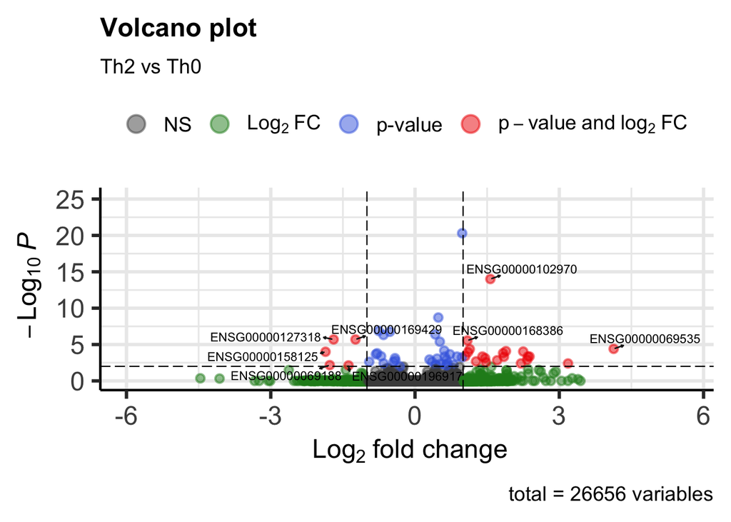

```r
# visual 1

EnhancedVolcano(res, lab = rownames(res),
                x = 'log2FoldChange', y = 'padj',
                subtitle = 'Th2 vs Th0', labSize = 3,
                pCutoff = 0.01,
                FCcutoff = 1,
                drawConnectors = TRUE)
```

```r
# x axis log fold change: how strong is the change
# y axis is the p-value
```

A volcano plot visualizes **differential expression results** by combining **statistical significance** and **magnitude of change**:

- **X-axis:** log₂ fold change (direction and magnitude of expression change)
- **Y-axis:** -log₁₀(p-value) (statistical significance)
- **Points color-coded:**
  - **Gray (NS):** not significant
  - **Green:** significant by log₂FC only
  - **Blue:** significant by p-value only
  - **Red:** significant by both log₂FC and p-value

**Observations:**

- Most red points are located at **high absolute log₂FC values**, showing genes with strong and statistically significant differential expression.
- Genes near the center (between vertical dotted lines) are statistically significant but with **small fold changes** → less biologically meaningful.
- Some genes have **very high log₂FC and low p-values**, making them prime candidates for downstream functional analysis.

**Takeaway:** The volcano plot highlights a **subset of genes with strong, significant changes** between Th2 and Th0, which aligns with the patterns observed in the heatmap.

```r
# visual 2: heatmap

DEG.idx <- which(res$padj <= 0.01 &
      abs(res$log2FoldChange) > 1)
res[DEG.idx,]
```

```
## log2 fold change (MLE): cytokine condition Th2 vs Th0
## Wald test p-value: cytokine condition Th2 vs Th0
## DataFrame with 25 rows and 6 columns
##                  baseMean log2FoldChange     lfcSE      stat      pvalue
##                 <numeric>      <numeric> <numeric> <numeric>   <numeric>
## ENSG00000158125   55.3416       -1.86081  0.345086  -5.39230 6.95609e-08
## ENSG00000115896  259.0013        1.04492  0.206308   5.06484 4.08737e-07
## ENSG00000091181   38.7084        1.83120  0.345994   5.29257 1.20607e-07
## ENSG00000168386  138.2252        1.08978  0.179103   6.08468 1.16723e-09
## ENSG00000169429 1005.5434       -1.23768  0.201104  -6.15443 7.53456e-10
## ...                   ...            ...       ...       ...         ...
## ENSG00000092068  214.5830        1.47597  0.323572   4.56147 5.07972e-06
## ENSG00000102970  202.8555        1.56695  0.176911   8.85726 8.20053e-19
## ENSG00000069188   98.4945       -1.77297  0.409486  -4.32975 1.49276e-05
## ENSG00000101695 4525.4228        1.26926  0.273535   4.64023 3.48026e-06
## ENSG00000124212  277.0815        1.40168  0.279146   5.02130 5.13230e-07
##                        padj
##                   <numeric>
## ENSG00000158125 9.84982e-05
## ENSG00000115896 4.09964e-04
## ENSG00000091181 1.52803e-04
## ENSG00000168386 2.80976e-06
## ENSG00000169429 2.01524e-06
## ...                     ...
## ENSG00000092068 2.77907e-03
## ENSG00000102970 9.87016e-15
## ENSG00000069188 6.77994e-03
## ENSG00000101695 2.09442e-03
## ENSG00000124212 4.49525e-04
```

```r
df <- as.data.frame(colData(dds)[,c("cytokine_condition","donor_id", "sequencing_batch")])
```

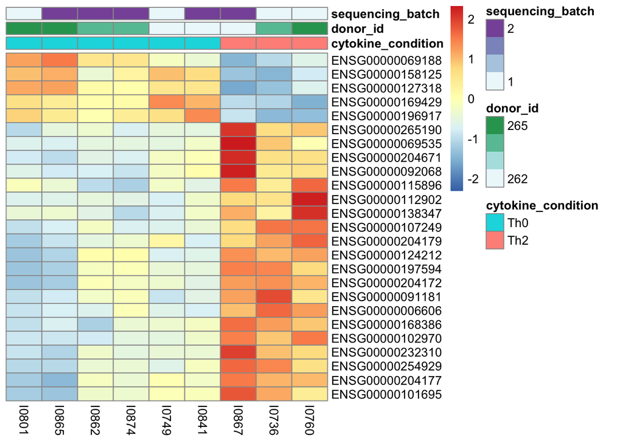

```r
pheatmap(assay(rltfd)[DEG.idx,], annotation_col=df,
    treeheight_row = 0, treeheight_col = 0, scale = "row")
```

- The heatmap shows **expression patterns of differentially expressed genes (DEGs)** across samples.
- **Rows:** genes (DEGs filtered by adjusted p-value ≤ 0.01 and |log₂FC| > 1)
- **Columns:** samples
- **Annotations:**
  - `cytokine_condition` (Th0 vs Th2)
  - `donor_id`
  - `sequencing_batch`

**Observations:**

- Clear separation between Th0 and Th2 samples — upregulated genes in Th2 are shown in **warm colors (orange/red)**, downregulated in **cool colors (blue)**.
- Minimal batch effect visible — samples from different sequencing batches cluster largely by condition, not batch.
- Donor variation is present but secondary to the treatment effect.

**Takeaway:** The heatmap confirms that the DEGs reflect **biologically meaningful differences between Th2 and Th0 conditions**.

## Overall conclusion:

- Both visualizations confirm that **Th2 treatment induces clear transcriptional changes** in CD4⁺ memory cells.
- Red genes in the volcano plot correspond to the most strongly up- or downregulated genes in the heatmap.
- These genes are **primary candidates for functional analysis** to understand the biological effect of the treatment.